# CFTC Historical Data:Futures Only Reports

アセット･マネジメント･コンサルティング株式会社 http://am-consulting.co.jp

2017-07-10 04:26:26

- アセット･マネジメント･コンサルティング株式会社 http://am-consulting.co.jp
- SaECaNet http://saecanet.com/
- Olive http://olive.saecanet.com/
- twitter https://twitter.com/AMC2_Japan
- 本ページへのリンクを共有:[Tweet](https://twitter.com/share)
- タイトル : CFTC Historical Data:Futures Only Reports:2017-07-03
- データ出所 : Commodity Futures Trading Commission
- Source http://www.cftc.gov/index.htm

#### Latest Result

- ID:1. WHEAT-SRW - CHICAGO BOARD OF TRADE

| Date | Noncommercial Positions-Net (All) | Commercial Positions-Net (All) | Unit |
| --- | --- | --- | --- |
| 2017-07-03 | 14,757 | -4,348 | (CONTRACTS OF 5,000 BUSHELS) |

- ID:2. WHEAT-HRW - CHICAGO BOARD OF TRADE

| Date | Noncommercial Positions-Net (All) | Commercial Positions-Net (All) | Unit |
| --- | --- | --- | --- |
| 2017-07-03 | 76,286 | -74,384 | (CONTRACTS OF 5,000 BUSHELS) |

- ID:3. WHEAT-HRSpring - MINNEAPOLIS GRAIN EXCHANGE

| Date | Noncommercial Positions-Net (All) | Commercial Positions-Net (All) | Unit |
| --- | --- | --- | --- |
| 2017-07-03 | 9,379 | -15,931 | (CONTRACTS OF 5,000 BUSHELS) |

- ID:4. CORN - CHICAGO BOARD OF TRADE

| Date | Noncommercial Positions-Net (All) | Commercial Positions-Net (All) | Unit |
| --- | --- | --- | --- |
| 2017-07-03 | 43,480 | -44,558 | (CONTRACTS OF 5,000 BUSHELS) |

- ID:5. OATS - CHICAGO BOARD OF TRADE

| Date | Noncommercial Positions-Net (All) | Commercial Positions-Net (All) | Unit |
| --- | --- | --- | --- |
| 2017-07-03 | 2,206 | -3,851 | (CONTRACTS OF 5,000 BUSHELS) |

- ID:6. SOYBEANS - CHICAGO BOARD OF TRADE

| Date | Noncommercial Positions-Net (All) | Commercial Positions-Net (All) | Unit |
| --- | --- | --- | --- |
| 2017-07-03 | -59,429 | 91,780 | (CONTRACTS OF 5,000 BUSHELS) |

- ID:8. CALIF CARBON ALL VINTAGE 2016 - ICE FUTURES ENERGY DIV

| Date | Noncommercial Positions-Net (All) | Commercial Positions-Net (All) | Unit |
| --- | --- | --- | --- |
| 2017-06-27 | 190 | -208 | 1,000 california carbon allowances |

- ID:9. NJ SRECS VINTAGE 2017 - ICE FUTURES ENERGY DIV

| Date | Noncommercial Positions-Net (All) | Commercial Positions-Net (All) | Unit |
| --- | --- | --- | --- |
| 2017-07-03 | 7,136 | -7,136 | (10 SRECs) |

- ID:10. NJ SRECS VINTAGE 2018 - ICE FUTURES ENERGY DIV

| Date | Noncommercial Positions-Net (All) | Commercial Positions-Net (All) | Unit |
| --- | --- | --- | --- |
| 2017-07-03 | -5,037 | 5,037 | (10 SRECs) |

- ID:11. CALIF CARBON ALL VINTAGE 2017 - ICE FUTURES ENERGY DIV

| Date | Noncommercial Positions-Net (All) | Commercial Positions-Net (All) | Unit |
| --- | --- | --- | --- |
| 2017-07-03 | -4,698 | 4,743 | 1,000 california carbon allowances |

- ID:12. RGGI VINTAGE 2016 - ICE FUTURES ENERGY DIV

| Date | Noncommercial Positions-Net (All) | Commercial Positions-Net (All) | Unit |
| --- | --- | --- | --- |
| 2017-07-03 | 7,093 | -7,093 | 1,000 RGGI CO2 Allowances |

- ID:13. NJ SRECS VINTAGE 2019 - ICE FUTURES ENERGY DIV

| Date | Noncommercial Positions-Net (All) | Commercial Positions-Net (All) | Unit |
| --- | --- | --- | --- |
| 2017-07-03 | -8,698 | 8,698 | (10 SRECs) |

- ID:14. NJ SRECS VINTAGE 2020 - ICE FUTURES ENERGY DIV

| Date | Noncommercial Positions-Net (All) | Commercial Positions-Net (All) | Unit |
| --- | --- | --- | --- |
| 2017-07-03 | -1,335 | 1,335 | (10 SRECs) |

- ID:15. PJM TRI-RECs CLASS 1 Vin 2017 - ICE FUTURES ENERGY DIV

| Date | Noncommercial Positions-Net (All) | Commercial Positions-Net (All) | Unit |
| --- | --- | --- | --- |
| 2017-07-03 | 1,810 | -1,810 | 100 MWh of renewable energy certificates |

- ID:16. PJM TRI-RECs CLASS 1 Vin 2018 - ICE FUTURES ENERGY DIV

| Date | Noncommercial Positions-Net (All) | Commercial Positions-Net (All) | Unit |
| --- | --- | --- | --- |
| 2017-07-03 | 5 | -5 | 100 MWh of renewable energy certificates |

- ID:17. PJM TRI-RECs CLASS 1 Vin 2019 - ICE FUTURES ENERGY DIV

| Date | Noncommercial Positions-Net (All) | Commercial Positions-Net (All) | Unit |
| --- | --- | --- | --- |
| 2017-07-03 | 2,138 | -2,138 | 100 MWh of renewable energy certificates |

- ID:18. RGGI VINTAGE 2017 - ICE FUTURES ENERGY DIV

| Date | Noncommercial Positions-Net (All) | Commercial Positions-Net (All) | Unit |
| --- | --- | --- | --- |
| 2017-07-03 | -1,595 | 1,575 | 1,000 RGGI CO2 Allowances |

- ID:19. SOYBEAN OIL - CHICAGO BOARD OF TRADE

| Date | Noncommercial Positions-Net (All) | Commercial Positions-Net (All) | Unit |
| --- | --- | --- | --- |
| 2017-07-03 | 35,966 | -45,878 | (CONTRACTS OF 60,000 POUNDS) |

- ID:20. U.S. TREASURY BONDS - CHICAGO BOARD OF TRADE

| Date | Noncommercial Positions-Net (All) | Commercial Positions-Net (All) | Unit |
| --- | --- | --- | --- |
| 2017-07-03 | 67,021 | -63,797 | (CONTRACTS OF $100,000 FACE VALUE) |

- ID:21. ULTRA U.S. TREASURY BONDS - CHICAGO BOARD OF TRADE

| Date | Noncommercial Positions-Net (All) | Commercial Positions-Net (All) | Unit |
| --- | --- | --- | --- |
| 2017-07-03 | -64,185 | 40,607 | (CONTRACTS OF $100,000 FACE VALUE) |

- ID:22. GULF # 6 FUEL 3.0% SULFUR SWAP - NEW YORK MERCANTILE EXCHANGE

| Date | Noncommercial Positions-Net (All) | Commercial Positions-Net (All) | Unit |
| --- | --- | --- | --- |
| 2017-07-03 | 4,776 | -4,781 | (CONTRACTS OF 1,000 BARRELS) |

- ID:24. EUR 3.5% FUEL OIL RTD CAL SWAP - NEW YORK MERCANTILE EXCHANGE

| Date | Noncommercial Positions-Net (All) | Commercial Positions-Net (All) | Unit |
| --- | --- | --- | --- |
| 2017-07-03 | 491 | -719 | (CONTRACTS OF 1,000 METRIC TONS) |

- ID:26. SING 380 FUEL OIL SWAP - NEW YORK MERCANTILE EXCHANGE

| Date | Noncommercial Positions-Net (All) | Commercial Positions-Net (All) | Unit |
| --- | --- | --- | --- |
| 2017-07-03 | 624 | -788 | (CONTRACTS OF 1,000 METRIC TONS) |

- ID:28. MINI EUR 3.5%FOIL RTD CAL SWAP - NEW YORK MERCANTILE EXCHANGE

| Date | Noncommercial Positions-Net (All) | Commercial Positions-Net (All) | Unit |
| --- | --- | --- | --- |
| 2017-07-03 | -1,154 | 887 | (CONTRACTS OF 100 METRIC TONS) |

- ID:29. MINI SING FUELOIL 180 CAL SWAP - NEW YORK MERCANTILE EXCHANGE

| Date | Noncommercial Positions-Net (All) | Commercial Positions-Net (All) | Unit |
| --- | --- | --- | --- |
| 2017-07-03 | -614 | 599 | (CONTRACTS OF 100 METRIC TONS) |

- ID:30. GULF NO6 FO 3% v EUR 3.5% RDAM - NEW YORK MERCANTILE EXCHANGE

| Date | Noncommercial Positions-Net (All) | Commercial Positions-Net (All) | Unit |
| --- | --- | --- | --- |
| 2017-07-03 | -2,697 | 2,687 | (CONTRACTS OF 1,000 BARRELS) |

- ID:31. MINI SING 380 FUEL OIL SWAP - NEW YORK MERCANTILE EXCHANGE

| Date | Noncommercial Positions-Net (All) | Commercial Positions-Net (All) | Unit |
| --- | --- | --- | --- |
| 2017-07-03 | -1,155 | 808 | (CONTRACTS OF 100 METRIC TONS) |

- ID:32. FUEL OIL-380cst SING/3.5% RDAM - NEW YORK MERCANTILE EXCHANGE

| Date | Noncommercial Positions-Net (All) | Commercial Positions-Net (All) | Unit |
| --- | --- | --- | --- |
| 2017-07-03 | 10 | -357 | 1000 metric tons |

- ID:33. #2 HEATING OIL, NY HARBOR-ULSD - NEW YORK MERCANTILE EXCHANGE

| Date | Noncommercial Positions-Net (All) | Commercial Positions-Net (All) | Unit |
| --- | --- | --- | --- |
| 2017-07-03 | 3,775 | -1,483 | (CONTRACTS OF 42,000 U.S. GALLONS) |

- ID:35. UP DOWN GC ULSD VS HO SPR - NEW YORK MERCANTILE EXCHANGE

| Date | Noncommercial Positions-Net (All) | Commercial Positions-Net (All) | Unit |
| --- | --- | --- | --- |
| 2017-07-03 | -25 | -5,898 | (CONTRACTS OF 42,000 GALLONS) |

- ID:36. NATURAL GAS ICE HENRY HUB - ICE FUTURES ENERGY DIV

| Date | Noncommercial Positions-Net (All) | Commercial Positions-Net (All) | Unit |
| --- | --- | --- | --- |
| 2017-07-03 | 929,831 | -955,392 | 2500 MMBtus |

- ID:37. NATURAL GAS PENULTIMATE ICE - ICE FUTURES ENERGY DIV

| Date | Noncommercial Positions-Net (All) | Commercial Positions-Net (All) | Unit |
| --- | --- | --- | --- |
| 2017-07-03 | -50,660 | 48,208 | 2500 mmbtu |

- ID:38. SOCAL BORDER FIN BASIS - ICE FUTURES ENERGY DIV

| Date | Noncommercial Positions-Net (All) | Commercial Positions-Net (All) | Unit |
| --- | --- | --- | --- |
| 2017-07-03 | 7,323 | -19,907 | (Contracts of 2,500 MMBTU’S) |

- ID:39. PG&E CITYGATE FIN BASIS - ICE FUTURES ENERGY DIV

| Date | Noncommercial Positions-Net (All) | Commercial Positions-Net (All) | Unit |
| --- | --- | --- | --- |
| 2017-07-03 | 868 | -1,094 | (Contracts of 2,500 MMBTU’S) |

- ID:40. NWP ROCKIES FIN BASIS - ICE FUTURES ENERGY DIV

| Date | Noncommercial Positions-Net (All) | Commercial Positions-Net (All) | Unit |
| --- | --- | --- | --- |
| 2017-07-03 | 8 | -5,965 | (Contracts of 2,500 MMBTU’S) |

- ID:41. AECO FIN BASIS - ICE FUTURES ENERGY DIV

| Date | Noncommercial Positions-Net (All) | Commercial Positions-Net (All) | Unit |
| --- | --- | --- | --- |
| 2017-07-03 | -17,635 | 12,639 | (Contracts of 2,500 MMBTU’S) |

- ID:42. CHICAGO FIN BASIS - ICE FUTURES ENERGY DIV

| Date | Noncommercial Positions-Net (All) | Commercial Positions-Net (All) | Unit |
| --- | --- | --- | --- |
| 2017-07-03 | 7,547 | -16,126 | (Contracts of 2,500 MMBTU’S) |

- ID:43. HSC FIN BASIS - ICE FUTURES ENERGY DIV

| Date | Noncommercial Positions-Net (All) | Commercial Positions-Net (All) | Unit |
| --- | --- | --- | --- |
| 2017-07-03 | 3,925 | -15,021 | (Contracts of 2,500 MMBTU’S) |

- ID:44. WAHA FIN BASIS - ICE FUTURES ENERGY DIV

| Date | Noncommercial Positions-Net (All) | Commercial Positions-Net (All) | Unit |
| --- | --- | --- | --- |
| 2017-07-03 | -1,201 | 2,515 | (Contracts of 2,500 MMBTU’S) |

- ID:45. ALGONQUIN CITY-GATES FINANCIAL BASIS - ICE FUTURES ENERGY DIV

| Date | Noncommercial Positions-Net (All) | Commercial Positions-Net (All) | Unit |
| --- | --- | --- | --- |
| 2017-07-03 | -1,033 | 4,288 | 2500 mmbtu |

- ID:46. CHICAGO CITYGATE (INDEX) - ICE FUTURES ENERGY DIV

| Date | Noncommercial Positions-Net (All) | Commercial Positions-Net (All) | Unit |
| --- | --- | --- | --- |
| 2017-07-03 | 1,013 | -1,129 | 2500 mmbtu |

- ID:47. COLORADO INTERSTATE - MAINLINE (BASIS) - ICE FUTURES ENERGY DIV

| Date | Noncommercial Positions-Net (All) | Commercial Positions-Net (All) | Unit |
| --- | --- | --- | --- |
| 2017-07-03 | -1,399 | -647 | 2500 mmbtu |

- ID:48. COLUMBIA GAS CO. - TCO POOL (APPALACHIA) (BASIS) - ICE FUTURES ENERGY DIV

| Date | Noncommercial Positions-Net (All) | Commercial Positions-Net (All) | Unit |
| --- | --- | --- | --- |
| 2017-07-03 | 0 | -4,251 | 2500 mm btu |

- ID:49. COLUMBIA GULF TRANSMISSION CO. - MAINLINE POOL - ICE FUTURES ENERGY DIV

| Date | Noncommercial Positions-Net (All) | Commercial Positions-Net (All) | Unit |
| --- | --- | --- | --- |
| 2017-07-03 | 0 | -1,432 | 2500 mmbtu |

- ID:50. DOMINION - SOUTH POINT - ICE FUTURES ENERGY DIV

| Date | Noncommercial Positions-Net (All) | Commercial Positions-Net (All) | Unit |
| --- | --- | --- | --- |
| 2017-07-03 | 538 | -526 | 2500 mmbtu |

- ID:51. DOMINION - SOUTH POINT (BASIS) - ICE FUTURES ENERGY DIV

| Date | Noncommercial Positions-Net (All) | Commercial Positions-Net (All) | Unit |
| --- | --- | --- | --- |
| 2017-07-03 | 43,888 | -42,295 | 2500 mmbtu |

- ID:52. EL PASO - PERMIAN BASIN (BASIS) - ICE FUTURES ENERGY DIV

| Date | Noncommercial Positions-Net (All) | Commercial Positions-Net (All) | Unit |
| --- | --- | --- | --- |
| 2017-07-03 | -698 | -2,536 | 2500 mmbtu |

- ID:53. EL PASO - PERMIAN BASIN (INDEX) - ICE FUTURES ENERGY DIV

| Date | Noncommercial Positions-Net (All) | Commercial Positions-Net (All) | Unit |
| --- | --- | --- | --- |
| 2017-07-03 | 1,156 | -1,568 | 2500 mmbtu |

- ID:54. EL PASO-SAN JUAN BASIN,BLANCO POOL PRIMARY ONLY-BASIS - ICE FUTURES ENERGY D

| Date | Noncommercial Positions-Net (All) | Commercial Positions-Net (All) | Unit |
| --- | --- | --- | --- |
| 2017-07-03 | -948 | 2,529 | 2500 mmbtu |

- ID:55. HENRY HUB - TAILGATE, LOUISIANA (BASIS) - ICE FUTURES ENERGY DIV

| Date | Noncommercial Positions-Net (All) | Commercial Positions-Net (All) | Unit |
| --- | --- | --- | --- |
| 2017-07-03 | 22,785 | -20,518 | 2500 mmbtu |

- ID:56. HENRY HUB - TAILGATE, LOUISIANA (INDEX) - ICE FUTURES ENERGY DIV

| Date | Noncommercial Positions-Net (All) | Commercial Positions-Net (All) | Unit |
| --- | --- | --- | --- |
| 2017-07-03 | 52,555 | -53,504 | 2500 mmbtu |

- ID:57. HOUSTON SHIP CHANNEL (INDEX) - ICE FUTURES ENERGY DIV

| Date | Noncommercial Positions-Net (All) | Commercial Positions-Net (All) | Unit |
| --- | --- | --- | --- |
| 2017-07-03 | -2,347 | 5,151 | 2500 mmbtu |

- ID:59. MICHIGAN CONSOLIDATED CITYGATE (GENERIC) (BASIS) - ICE FUTURES ENERGY DIV

| Date | Noncommercial Positions-Net (All) | Commercial Positions-Net (All) | Unit |
| --- | --- | --- | --- |
| 2017-07-03 | -259 | -170 | 2500 mmbtu |

- ID:60. NATURAL GAS INDEX: ALGONQUIN CITY GATES - ICE FUTURES ENERGY DIV

| Date | Noncommercial Positions-Net (All) | Commercial Positions-Net (All) | Unit |
| --- | --- | --- | --- |
| 2017-07-03 | -356 | -771 | mmbtu |

- ID:62. NATURAL GAS PIPELINE, TEXOK (BASIS) - ICE FUTURES ENERGY DIV

| Date | Noncommercial Positions-Net (All) | Commercial Positions-Net (All) | Unit |
| --- | --- | --- | --- |
| 2017-07-03 | -1,192 | -1,258 | 2500 mmbtu |

- ID:64. NORTHERN NATURAL GAS - VENTURA (BASIS) - ICE FUTURES ENERGY DIV

| Date | Noncommercial Positions-Net (All) | Commercial Positions-Net (All) | Unit |
| --- | --- | --- | --- |
| 2017-07-03 | 4,432 | -4,528 | 2500 mmbtu |

- ID:65. NORTHWEST PIPELINE - CANADIAN BORDER (BASIS) - ICE FUTURES ENERGY DIV

| Date | Noncommercial Positions-Net (All) | Commercial Positions-Net (All) | Unit |
| --- | --- | --- | --- |
| 2017-07-03 | 0 | -9,956 | 2500 mmbtu |

- ID:66. NORTHWEST PIPELINE CORP. - ROCKY MOUNTAINS - ICE FUTURES ENERGY DIV

| Date | Noncommercial Positions-Net (All) | Commercial Positions-Net (All) | Unit |
| --- | --- | --- | --- |
| 2017-07-03 | 178 | -265 | 2500 mmbtu |

- ID:67. PACIFIC GAS TRANSMISSION - MALIN (BASIS) - ICE FUTURES ENERGY DIV

| Date | Noncommercial Positions-Net (All) | Commercial Positions-Net (All) | Unit |
| --- | --- | --- | --- |
| 2017-07-03 | 521 | -4,986 | 2500 mmbtu |

- ID:68. PANHANDLE EASTERN- POOL GAS (BASIS) - ICE FUTURES ENERGY DIV

| Date | Noncommercial Positions-Net (All) | Commercial Positions-Net (All) | Unit |
| --- | --- | --- | --- |
| 2017-07-03 | -6,455 | 6,806 | 2500 mmbtu |

- ID:70. SOCAL (INDEX) - ICE FUTURES ENERGY DIV

| Date | Noncommercial Positions-Net (All) | Commercial Positions-Net (All) | Unit |
| --- | --- | --- | --- |
| 2017-07-03 | 900 | -1,639 | 2500 mmbtu |

- ID:71. TEXAS EASTERN- M3 ZONE (DELIVERED) - ICE FUTURES ENERGY DIV

| Date | Noncommercial Positions-Net (All) | Commercial Positions-Net (All) | Unit |
| --- | --- | --- | --- |
| 2017-07-03 | 3,021 | -2,565 | 2500 mmbtu |

- ID:72. TEXAS EASTERN- M3 ZONE (DELIVERED) (BASIS) - ICE FUTURES ENERGY DIV

| Date | Noncommercial Positions-Net (All) | Commercial Positions-Net (All) | Unit |
| --- | --- | --- | --- |
| 2017-07-03 | 10,313 | -8,367 | 2500 mm btu |

- ID:73. TRANSCO STN 85 MONTHLY INDEX - ICE FUTURES ENERGY DIV

| Date | Noncommercial Positions-Net (All) | Commercial Positions-Net (All) | Unit |
| --- | --- | --- | --- |
| 2017-07-03 | 0 | -367 | mmbtu |

- ID:74. TRANSCO ZONE 6 BASIS - ICE FUTURES ENERGY DIV

| Date | Noncommercial Positions-Net (All) | Commercial Positions-Net (All) | Unit |
| --- | --- | --- | --- |
| 2017-07-03 | 1,444 | -3,250 | mmbtu |

- ID:75. TRANSCONTINENTAL GAS- STATION 85 (ZONE 4) - ICE FUTURES ENERGY DIV

| Date | Noncommercial Positions-Net (All) | Commercial Positions-Net (All) | Unit |
| --- | --- | --- | --- |
| 2017-07-03 | 0 | -4,136 | 2500 mm btu |

- ID:76. TRANSCONTINENTAL GAS - ZONE 6 (NY) (BASIS) - ICE FUTURES ENERGY DIV

| Date | Noncommercial Positions-Net (All) | Commercial Positions-Net (All) | Unit |
| --- | --- | --- | --- |
| 2017-07-03 | 3,088 | -2,751 | 2500 mm btu |

- ID:77. WAHA HUB - WEST TEXAS DELIVERED/BUYER’S INDEX - ICE FUTURES ENERGY DIV

| Date | Noncommercial Positions-Net (All) | Commercial Positions-Net (All) | Unit |
| --- | --- | --- | --- |
| 2017-07-03 | 3,867 | -3,922 | 2500 mm btu |

- ID:78. TETCO M2 Basis (Receipts) - ICE FUTURES ENERGY DIV

| Date | Noncommercial Positions-Net (All) | Commercial Positions-Net (All) | Unit |
| --- | --- | --- | --- |
| 2017-07-03 | 3,537 | -4,462 | 2500 MM Btus |

- ID:79. TRANSCO LEIDY BASIS - ICE FUTURES ENERGY DIV

| Date | Noncommercial Positions-Net (All) | Commercial Positions-Net (All) | Unit |
| --- | --- | --- | --- |
| 2017-07-03 | 0 | -4,139 | 2500 mm btu |

- ID:80. NATURAL GAS - NEW YORK MERCANTILE EXCHANGE

| Date | Noncommercial Positions-Net (All) | Commercial Positions-Net (All) | Unit |
| --- | --- | --- | --- |
| 2017-07-03 | -20,040 | -7,726 | (Contracts of 10,000 MMBTU’S) |

- ID:81. HENRY HUB LAST DAY FIN - NEW YORK MERCANTILE EXCHANGE

| Date | Noncommercial Positions-Net (All) | Commercial Positions-Net (All) | Unit |
| --- | --- | --- | --- |
| 2017-07-03 | 30,726 | -35,454 | (Contracts of 10,000 MMBTU’S) |

- ID:82. HENRY HUB PENULTIMATE FIN - NEW YORK MERCANTILE EXCHANGE

| Date | Noncommercial Positions-Net (All) | Commercial Positions-Net (All) | Unit |
| --- | --- | --- | --- |
| 2017-07-03 | -32,858 | 29,376 | (Contracts of 10,000 MMBTU’S) |

- ID:83. HHUB NAT GAS PENULT FINL-10000 - NASDAQ FUTURES

| Date | Noncommercial Positions-Net (All) | Commercial Positions-Net (All) | Unit |
| --- | --- | --- | --- |
| 2017-07-03 | -3,543 | 3,709 | (Contracts of 10,000 MMBTU’S) |

- ID:84. COAL (API 2) CIF ARA SWAP FUT - NEW YORK MERCANTILE EXCHANGE

| Date | Noncommercial Positions-Net (All) | Commercial Positions-Net (All) | Unit |
| --- | --- | --- | --- |
| 2017-07-03 | 5,140 | -5,520 | (CONTRACTS OF 1,000 METRIC TONS) |

- ID:85. COAL (API 4) FOB RICH BAY FUT - NEW YORK MERCANTILE EXCHANGE

| Date | Noncommercial Positions-Net (All) | Commercial Positions-Net (All) | Unit |
| --- | --- | --- | --- |
| 2017-07-03 | 4,757 | -4,872 | (CONTRACTS OF 1,000 METRIC TONS) |

- ID:86. CBT ETHANOL - CHICAGO BOARD OF TRADE

| Date | Noncommercial Positions-Net (All) | Commercial Positions-Net (All) | Unit |
| --- | --- | --- | --- |
| 2017-07-03 | 248 | -334 | (CONTRACTS OF 29,000 U.S. GALLONS) |

- ID:87. ETHANOL T2 FOB INCL DUTY SWAP - NEW YORK MERCANTILE EXCHANGE

| Date | Noncommercial Positions-Net (All) | Commercial Positions-Net (All) | Unit |
| --- | --- | --- | --- |
| 2017-07-03 | 229 | -386 | (100 CUBIC METERS) |

- ID:88. CHICAGO ETHANOL SWAP - NEW YORK MERCANTILE EXCHANGE

| Date | Noncommercial Positions-Net (All) | Commercial Positions-Net (All) | Unit |
| --- | --- | --- | --- |
| 2017-07-03 | 4,104 | -4,102 | (CONTRACTS OF 42,000 U.S. GALLONS) |

- ID:90. SOYBEAN MEAL - CHICAGO BOARD OF TRADE

| Date | Noncommercial Positions-Net (All) | Commercial Positions-Net (All) | Unit |
| --- | --- | --- | --- |
| 2017-07-03 | -19,934 | 16,656 | (CONTRACTS OF 100 TONS) |

- ID:91. EUROPEAN NAPHTHA CAL SWAP - NEW YORK MERCANTILE EXCHANGE

| Date | Noncommercial Positions-Net (All) | Commercial Positions-Net (All) | Unit |
| --- | --- | --- | --- |
| 2017-07-03 | 331 | -169 | (CONTRACTS OF 1,000 METRIC TONS) |

- ID:92. JAPAN C&F NAPHTHA SWAP - NEW YORK MERCANTILE EXCHANGE

| Date | Noncommercial Positions-Net (All) | Commercial Positions-Net (All) | Unit |
| --- | --- | --- | --- |
| 2017-07-03 | -136 | 153 | (CONTRACTS OF 1,000 METRIC TONS) |

- ID:93. Mini Eur Naphtha CIF NWE Swap - NEW YORK MERCANTILE EXCHANGE

| Date | Noncommercial Positions-Net (All) | Commercial Positions-Net (All) | Unit |
| --- | --- | --- | --- |
| 2017-07-03 | -666 | 415 | (CONTRACTS OF 100 METRIC TONS) |

- ID:94. COTTON NO. 2 - ICE FUTURES U.S.

| Date | Noncommercial Positions-Net (All) | Commercial Positions-Net (All) | Unit |
| --- | --- | --- | --- |
| 2017-07-03 | 32,885 | -31,014 | (CONTRACTS OF 50,000 POUNDS) |

- ID:95. HENRY HUB SWAP - NEW YORK MERCANTILE EXCHANGE

| Date | Noncommercial Positions-Net (All) | Commercial Positions-Net (All) | Unit |
| --- | --- | --- | --- |
| 2017-07-03 | 638,671 | -651,301 | (Contracts of 2,500 MMBTU’S) |

- ID:96. HENRY HUB PENULTIMATE GAS SWAP - NEW YORK MERCANTILE EXCHANGE

| Date | Noncommercial Positions-Net (All) | Commercial Positions-Net (All) | Unit |
| --- | --- | --- | --- |
| 2017-07-03 | -34,939 | 36,296 | (Contracts of 2,500 MMBTU’S) |

- ID:97. MALAYSIAN PALM OIL CALENDAR SW - CHICAGO MERCANTILE EXCHANGE

| Date | Noncommercial Positions-Net (All) | Commercial Positions-Net (All) | Unit |
| --- | --- | --- | --- |
| 2017-07-03 | -3,316 | 3,336 | (CONTRACTS OF 25 METRIC TONS) |

- ID:98. ROUGH RICE - CHICAGO BOARD OF TRADE

| Date | Noncommercial Positions-Net (All) | Commercial Positions-Net (All) | Unit |
| --- | --- | --- | --- |
| 2017-07-03 | 1,193 | -1,533 | (CONTRACTS OF 200,000 POUNDS) |

- ID:99. FRZN CONCENTRATED ORANGE JUICE - ICE FUTURES U.S.

| Date | Noncommercial Positions-Net (All) | Commercial Positions-Net (All) | Unit |
| --- | --- | --- | --- |
| 2017-07-03 | -2,149 | 2,213 | (CONTRACTS OF 15,000 POUNDS) |

- ID:100. 2-YEAR U.S. TREASURY NOTES - CHICAGO BOARD OF TRADE

| Date | Noncommercial Positions-Net (All) | Commercial Positions-Net (All) | Unit |
| --- | --- | --- | --- |
| 2017-07-03 | -257,187 | 301,962 | (CONTRACTS OF $200,000 FACE VALUE) |

- ID:101. 10-YEAR U.S. TREASURY NOTES - CHICAGO BOARD OF TRADE

| Date | Noncommercial Positions-Net (All) | Commercial Positions-Net (All) | Unit |
| --- | --- | --- | --- |
| 2017-07-03 | 262,962 | -101,597 | (CONTRACTS OF $100,000 FACE VALUE) |

- ID:102. ULTRA 10-YEAR U.S. T-NOTES - CHICAGO BOARD OF TRADE

| Date | Noncommercial Positions-Net (All) | Commercial Positions-Net (All) | Unit |
| --- | --- | --- | --- |
| 2017-07-03 | 28,969 | 6,051 | (CONTRACTS OF $100,000 FACE VALUE) |

- ID:103. 5-YEAR U.S. TREASURY NOTES - CHICAGO BOARD OF TRADE

| Date | Noncommercial Positions-Net (All) | Commercial Positions-Net (All) | Unit |
| --- | --- | --- | --- |
| 2017-07-03 | -219,293 | 323,450 | (CONTRACTS OF $100,000 FACE VALUE) |

- ID:104. 30-DAY FEDERAL FUNDS - CHICAGO BOARD OF TRADE

| Date | Noncommercial Positions-Net (All) | Commercial Positions-Net (All) | Unit |
| --- | --- | --- | --- |
| 2017-07-03 | -178,931 | 199,369 | (CONTRACTS OF $5,000,000) |

- ID:105. BUTTER (CASH SETTLED) - CHICAGO MERCANTILE EXCHANGE

| Date | Noncommercial Positions-Net (All) | Commercial Positions-Net (All) | Unit |
| --- | --- | --- | --- |
| 2017-07-03 | -213 | -301 | (CONTRACTS OF 20,000 POUNDS) |

- ID:106. MILK, Class III - CHICAGO MERCANTILE EXCHANGE

| Date | Noncommercial Positions-Net (All) | Commercial Positions-Net (All) | Unit |
| --- | --- | --- | --- |
| 2017-07-03 | 7,864 | -6,490 | (CONTRACTS OF 200,000 POUNDS) |

- ID:107. NON FAT DRY MILK - CHICAGO MERCANTILE EXCHANGE

| Date | Noncommercial Positions-Net (All) | Commercial Positions-Net (All) | Unit |
| --- | --- | --- | --- |
| 2017-07-03 | 220 | -304 | (CONTRACTS OF 44,000 LBS.) |

- ID:108. DRY WHEY - CHICAGO MERCANTILE EXCHANGE

| Date | Noncommercial Positions-Net (All) | Commercial Positions-Net (All) | Unit |
| --- | --- | --- | --- |
| 2017-06-27 | -3,732 | 3,132 | (CONTRACTS OF 44,000 LBS.) |

- ID:109. LEAN HOGS - CHICAGO MERCANTILE EXCHANGE

| Date | Noncommercial Positions-Net (All) | Commercial Positions-Net (All) | Unit |
| --- | --- | --- | --- |
| 2017-07-03 | 58,675 | -43,637 | (CONTRACTS OF 40,000 POUNDS) |

- ID:110. LIVE CATTLE - CHICAGO MERCANTILE EXCHANGE

| Date | Noncommercial Positions-Net (All) | Commercial Positions-Net (All) | Unit |
| --- | --- | --- | --- |
| 2017-07-03 | 120,005 | -97,087 | (CONTRACTS OF 40,000 POUNDS) |

- ID:111. RANDOM LENGTH LUMBER - CHICAGO MERCANTILE EXCHANGE

| Date | Noncommercial Positions-Net (All) | Commercial Positions-Net (All) | Unit |
| --- | --- | --- | --- |
| 2017-07-03 | -112 | -321 | (CONTRACTS OF 110,000 BOARD FEET) |

- ID:112. FEEDER CATTLE - CHICAGO MERCANTILE EXCHANGE

| Date | Noncommercial Positions-Net (All) | Commercial Positions-Net (All) | Unit |
| --- | --- | --- | --- |
| 2017-07-03 | 15,220 | -3,881 | (CONTRACTS OF 50,000 POUNDS) |

- ID:113. CHEESE (CASH-SETTLED) - CHICAGO MERCANTILE EXCHANGE

| Date | Noncommercial Positions-Net (All) | Commercial Positions-Net (All) | Unit |
| --- | --- | --- | --- |
| 2017-07-03 | -10,695 | 10,960 | (CONTRACTS OF 20,000 POUNDS) |

- ID:114. PJM WH REAL TIME PEAK - ICE FUTURES ENERGY DIV

| Date | Noncommercial Positions-Net (All) | Commercial Positions-Net (All) | Unit |
| --- | --- | --- | --- |
| 2017-07-03 | 10,554 | -10,495 | (Contracts of 800 MWh) |

- ID:115. MID-C DAY-AHEAD PEAK - ICE FUTURES ENERGY DIV

| Date | Noncommercial Positions-Net (All) | Commercial Positions-Net (All) | Unit |
| --- | --- | --- | --- |
| 2017-07-03 | 550 | -550 | (Contracts of 400 MWh) |

- ID:116. MID-C DAY-AHEAD OFF-PEAK - ICE FUTURES ENERGY DIV

| Date | Noncommercial Positions-Net (All) | Commercial Positions-Net (All) | Unit |
| --- | --- | --- | --- |
| 2017-07-03 | 600 | -384 | (Contracts of 25 MWh) |

- ID:117. PJM WESTERN HUB RT OFF - ICE FUTURES ENERGY DIV

| Date | Noncommercial Positions-Net (All) | Commercial Positions-Net (All) | Unit |
| --- | --- | --- | --- |
| 2017-07-03 | -28,018 | 27,977 | (Contracts of 50 Megawatt Hours) |

- ID:118. SP15 FIN DA PEAK FIXED - ICE FUTURES ENERGY DIV

| Date | Noncommercial Positions-Net (All) | Commercial Positions-Net (All) | Unit |
| --- | --- | --- | --- |
| 2017-07-03 | -6,221 | 6,198 | (Contracts of 400 Megawatt Hours) |

- ID:119. CAISO SP15 FIN DA OFF-PEAK - ICE FUTURES ENERGY DIV

| Date | Noncommercial Positions-Net (All) | Commercial Positions-Net (All) | Unit |
| --- | --- | --- | --- |
| 2017-07-03 | -250 | 243 | (Contracts of 25 Megawatt Hours) |

- ID:120. PJM AEP DAYTON RT OFF-PK - ICE FUTURES ENERGY DIV

| Date | Noncommercial Positions-Net (All) | Commercial Positions-Net (All) | Unit |
| --- | --- | --- | --- |
| 2017-07-03 | -3,562 | 3,583 | 50 Mwh |

- ID:121. PJM AEP DAYTON RT PEAK FIXED - ICE FUTURES ENERGY DIV

| Date | Noncommercial Positions-Net (All) | Commercial Positions-Net (All) | Unit |
| --- | --- | --- | --- |
| 2017-07-03 | -682 | 868 | 800MWh |

- ID:122. PJM AEP DAYTON HUB DA OFF-PK - ICE FUTURES ENERGY DIV

| Date | Noncommercial Positions-Net (All) | Commercial Positions-Net (All) | Unit |
| --- | --- | --- | --- |
| 2017-07-03 | -16,975 | 16,748 | 1 MW |

- ID:124. PJM AEP DAYTON DA PEAK - ICE FUTURES ENERGY DIV

| Date | Noncommercial Positions-Net (All) | Commercial Positions-Net (All) | Unit |
| --- | --- | --- | --- |
| 2017-07-03 | -16,839 | 16,787 | 1 MW |

- ID:125. MISO INDIANA OFF-PEAK - ICE FUTURES ENERGY DIV

| Date | Noncommercial Positions-Net (All) | Commercial Positions-Net (All) | Unit |
| --- | --- | --- | --- |
| 2017-07-03 | -300 | 276 | 1 MW |

- ID:126. MISO IN. REAL-TIME OFF-PEAK - ICE FUTURES ENERGY DIV

| Date | Noncommercial Positions-Net (All) | Commercial Positions-Net (All) | Unit |
| --- | --- | --- | --- |
| 2017-07-03 | 2,175 | -2,031 | 50 Mwh |

- ID:127. ERCOT HOUSTON 345KV RT PK FIX - ICE FUTURES ENERGY DIV

| Date | Noncommercial Positions-Net (All) | Commercial Positions-Net (All) | Unit |
| --- | --- | --- | --- |
| 2017-07-03 | -800 | 800 | 800 Mwh |

- ID:128. ERCOT NORTH 345KV RT PK FIX - ICE FUTURES ENERGY DIV

| Date | Noncommercial Positions-Net (All) | Commercial Positions-Net (All) | Unit |
| --- | --- | --- | --- |
| 2017-07-03 | -2,285 | 2,355 | 800 Mwh |

- ID:129. ERCOT - NORTH MONTHLY OFF-PEAK - ICE FUTURES ENERGY DIV

| Date | Noncommercial Positions-Net (All) | Commercial Positions-Net (All) | Unit |
| --- | --- | --- | --- |
| 2017-07-03 | 18 | 127 | 1 MW |

- ID:130. NYISO ZONE C DA PEAK - ICE FUTURES ENERGY DIV

| Date | Noncommercial Positions-Net (All) | Commercial Positions-Net (All) | Unit |
| --- | --- | --- | --- |
| 2017-07-03 | -585 | 245 | 1 MW |

- ID:131. MISO IN. DAY-AHEAD PEAK - ICE FUTURES ENERGY DIV

| Date | Noncommercial Positions-Net (All) | Commercial Positions-Net (All) | Unit |
| --- | --- | --- | --- |
| 2017-07-03 | -350 | 235 | 1 MW |

- ID:133. MISO INDIANA HUB RT PEAK - ICE FUTURES ENERGY DIV

| Date | Noncommercial Positions-Net (All) | Commercial Positions-Net (All) | Unit |
| --- | --- | --- | --- |
| 2017-07-03 | 375 | -375 | 800 Mwh |

- ID:136. PJM N. IL HUB DA OFF-PK - ICE FUTURES ENERGY DIV

| Date | Noncommercial Positions-Net (All) | Commercial Positions-Net (All) | Unit |
| --- | --- | --- | --- |
| 2017-07-03 | 1,120 | -1,155 | 1 MW |

- ID:137. PJM N. IL HUB DA PEAK - ICE FUTURES ENERGY DIV

| Date | Noncommercial Positions-Net (All) | Commercial Positions-Net (All) | Unit |
| --- | --- | --- | --- |
| 2017-07-03 | -340 | 155 | 1 MW |

- ID:138. ISO NE MASS HUB DA OFF-PK - ICE FUTURES ENERGY DIV

| Date | Noncommercial Positions-Net (All) | Commercial Positions-Net (All) | Unit |
| --- | --- | --- | --- |
| 2017-07-03 | 662 | -370 | 50MWh |

- ID:139. ISO NE MASS HUB DA PEAK - ICE FUTURES ENERGY DIV

| Date | Noncommercial Positions-Net (All) | Commercial Positions-Net (All) | Unit |
| --- | --- | --- | --- |
| 2017-07-03 | 3,489 | -3,113 | 800MWh |

- ID:140. CAISO NP-15 PEAK - ICE FUTURES ENERGY DIV

| Date | Noncommercial Positions-Net (All) | Commercial Positions-Net (All) | Unit |
| --- | --- | --- | --- |
| 2017-07-03 | 925 | -925 | 400MWh |

- ID:141. PJM NI HUB RT OFF-PK - ICE FUTURES ENERGY DIV

| Date | Noncommercial Positions-Net (All) | Commercial Positions-Net (All) | Unit |
| --- | --- | --- | --- |
| 2017-07-03 | -2,881 | 2,849 | 50MWh |

- ID:142. PJM N. IL HUB RT PEAK - ICE FUTURES ENERGY DIV

| Date | Noncommercial Positions-Net (All) | Commercial Positions-Net (All) | Unit |
| --- | --- | --- | --- |
| 2017-07-03 | 2,825 | -2,725 | 800 MWh |

- ID:143. NYISO ZONE J DA PEAK - ICE FUTURES ENERGY DIV

| Date | Noncommercial Positions-Net (All) | Commercial Positions-Net (All) | Unit |
| --- | --- | --- | --- |
| 2017-07-03 | -2,592 | 2,597 | 800MWh |

- ID:144. NYISO ZONE J DA OFF-PK - ICE FUTURES ENERGY DIV

| Date | Noncommercial Positions-Net (All) | Commercial Positions-Net (All) | Unit |
| --- | --- | --- | --- |
| 2017-07-03 | -1,740 | 1,611 | 50MWh |

- ID:145. NYISO ZONE A DA PEAK - ICE FUTURES ENERGY DIV

| Date | Noncommercial Positions-Net (All) | Commercial Positions-Net (All) | Unit |
| --- | --- | --- | --- |
| 2017-07-03 | 1,422 | -1,798 | 800MWh |

- ID:146. NYISO ZONE A DA OFF-PK - ICE FUTURES ENERGY DIV

| Date | Noncommercial Positions-Net (All) | Commercial Positions-Net (All) | Unit |
| --- | --- | --- | --- |
| 2017-07-03 | 1,350 | -1,270 | 50 Mwh |

- ID:147. NYISO ZONE G DA PEAK - ICE FUTURES ENERGY DIV

| Date | Noncommercial Positions-Net (All) | Commercial Positions-Net (All) | Unit |
| --- | --- | --- | --- |
| 2017-07-03 | -7,026 | 6,654 | 800MWh |

- ID:148. NYISO ZONE G DA OFF-PK - ICE FUTURES ENERGY DIV

| Date | Noncommercial Positions-Net (All) | Commercial Positions-Net (All) | Unit |
| --- | --- | --- | --- |
| 2017-07-03 | -1,470 | 1,407 | 50MWh |

- ID:149. NYISO ZONE C DA OFF-PK - ICE FUTURES ENERGY DIV

| Date | Noncommercial Positions-Net (All) | Commercial Positions-Net (All) | Unit |
| --- | --- | --- | --- |
| 2017-07-03 | -195 | -115 | MW |

- ID:151. PALO VERDE DA PEAK - ICE FUTURES ENERGY DIV

| Date | Noncommercial Positions-Net (All) | Commercial Positions-Net (All) | Unit |
| --- | --- | --- | --- |
| 2017-07-03 | -1,400 | 1,396 | 400MWh |

- ID:152. PALO VERDE DA OFF-PK - ICE FUTURES ENERGY DIV

| Date | Noncommercial Positions-Net (All) | Commercial Positions-Net (All) | Unit |
| --- | --- | --- | --- |
| 2017-07-03 | -150 | 143 | 25 MWh |

- ID:153. PJM BGE ZONE DAY AHEAD OFF PEAK MONTHLY - ICE FUTURES ENERGY DIV

| Date | Noncommercial Positions-Net (All) | Commercial Positions-Net (All) | Unit |
| --- | --- | --- | --- |
| 2017-07-03 | 565 | -1,600 | 1 MW |

- ID:154. PJM BGE ZONE DAY AHEAD, PEAK MONTHLY - ICE FUTURES ENERGY DIV

| Date | Noncommercial Positions-Net (All) | Commercial Positions-Net (All) | Unit |
| --- | --- | --- | --- |
| 2017-07-03 | 245 | -490 | 1 MW |

- ID:155. PJM RT PEAK CAL 1X - ICE FUTURES ENERGY DIV

| Date | Noncommercial Positions-Net (All) | Commercial Positions-Net (All) | Unit |
| --- | --- | --- | --- |
| 2017-07-03 | 1,628 | -1,776 | Any Multiple of 800 800MWhs |

- ID:156. PJM JCPL ZONE DAY-AHEAD PEAK - ICE FUTURES ENERGY DIV

| Date | Noncommercial Positions-Net (All) | Commercial Positions-Net (All) | Unit |
| --- | --- | --- | --- |
| 2017-07-03 | 30 | -65 | 1 MW |

- ID:157. PJM PECO ZONE DA PEAK - ICE FUTURES ENERGY DIV

| Date | Noncommercial Positions-Net (All) | Commercial Positions-Net (All) | Unit |
| --- | --- | --- | --- |
| 2017-07-03 | 1,000 | -1,606 | 1 MW |

- ID:158. PJM PECO ZONE OFF-PEAK MONTHLY - ICE FUTURES ENERGY DIV

| Date | Noncommercial Positions-Net (All) | Commercial Positions-Net (All) | Unit |
| --- | --- | --- | --- |
| 2017-07-03 | 1,050 | -1,421 | 1 MW |

- ID:159. PJM PEPCO DA PEAK - ICE FUTURES ENERGY DIV

| Date | Noncommercial Positions-Net (All) | Commercial Positions-Net (All) | Unit |
| --- | --- | --- | --- |
| 2017-07-03 | -525 | 670 | 1 MW |

- ID:161. PJM PPL ZONE DAY AHEAD, OFF-PEAK MONTHLY - ICE FUTURES ENERGY DIV

| Date | Noncommercial Positions-Net (All) | Commercial Positions-Net (All) | Unit |
| --- | --- | --- | --- |
| 2017-07-03 | 751 | -751 | 1 MW |

- ID:162. PJM PPL ZONE DA PEAK - ICE FUTURES ENERGY DIV

| Date | Noncommercial Positions-Net (All) | Commercial Positions-Net (All) | Unit |
| --- | --- | --- | --- |
| 2017-07-03 | 873 | -993 | 1 MW |

- ID:163. PJM WESTERN HUB DA OFF-PK - ICE FUTURES ENERGY DIV

| Date | Noncommercial Positions-Net (All) | Commercial Positions-Net (All) | Unit |
| --- | --- | --- | --- |
| 2017-07-03 | -7,687 | 7,642 | 1 MW |

- ID:164. PJM WESTERN HUB DA PEAK - ICE FUTURES ENERGY DIV

| Date | Noncommercial Positions-Net (All) | Commercial Positions-Net (All) | Unit |
| --- | --- | --- | --- |
| 2017-07-03 | -16,302 | 16,282 | 1 MW |

- ID:165. PJM WESTERN HUB RT PEAK MINI - ICE FUTURES ENERGY DIV

| Date | Noncommercial Positions-Net (All) | Commercial Positions-Net (All) | Unit |
| --- | --- | --- | --- |
| 2017-07-03 | -11,011 | 11,044 | 1 MW |

- ID:167. PJM PSEG DAY-AHEAD PEAK - ICE FUTURES ENERGY DIV

| Date | Noncommercial Positions-Net (All) | Commercial Positions-Net (All) | Unit |
| --- | --- | --- | --- |
| 2017-07-03 | 1,565 | -1,855 | 1 MW |

- ID:168. PJM PSEG ZONE DAY-AHEAD OFF-PEAK - ICE FUTURES ENERGY DIV

| Date | Noncommercial Positions-Net (All) | Commercial Positions-Net (All) | Unit |
| --- | --- | --- | --- |
| 2017-07-03 | 970 | -1,185 | 1 MW |

- ID:171. PJM WESTERN PEAK REAL TIME - NEW YORK MERCANTILE EXCHANGE

| Date | Noncommercial Positions-Net (All) | Commercial Positions-Net (All) | Unit |
| --- | --- | --- | --- |
| 2017-07-03 | 15,008 | -15,008 | (Contracts of 80 Megawatt Hours-5MW per |

- ID:173. ISONE..H.INTERNAL_HUB_month_on_dap - NODAL EXCHANGE

| Date | Noncommercial Positions-Net (All) | Commercial Positions-Net (All) | Unit |
| --- | --- | --- | --- |
| 2017-07-03 | 0 | -40 | Megawatt Hours (MWh) |

- ID:174. ISONE..H.INTERNAL_HUB_month_off_dap - NODAL EXCHANGE

| Date | Noncommercial Positions-Net (All) | Commercial Positions-Net (All) | Unit |
| --- | --- | --- | --- |
| 2017-07-03 | 0 | -75 | Megawatt Hours (MWh) |

- ID:185. PJM.AEP-DAYTON HUB_month_on_dap - NODAL EXCHANGE

| Date | Noncommercial Positions-Net (All) | Commercial Positions-Net (All) | Unit |
| --- | --- | --- | --- |
| 2017-07-03 | -1,200 | 1,180 | Megawatt Hours (MWh) |

- ID:186. PJM.AEP-DAYTON HUB_month_off_dap - NODAL EXCHANGE

| Date | Noncommercial Positions-Net (All) | Commercial Positions-Net (All) | Unit |
| --- | --- | --- | --- |
| 2017-07-03 | -1,200 | 1,320 | Megawatt Hours (MWh) |

- ID:187. PJM.BGE_month_on_dap - NODAL EXCHANGE

| Date | Noncommercial Positions-Net (All) | Commercial Positions-Net (All) | Unit |
| --- | --- | --- | --- |
| 2017-07-03 | -15,245 | 15,055 | Megawatt Hours (MWh) |

- ID:188. PJM.BGE_month_off_dap - NODAL EXCHANGE

| Date | Noncommercial Positions-Net (All) | Commercial Positions-Net (All) | Unit |
| --- | --- | --- | --- |
| 2017-07-03 | -12,425 | 12,235 | Megawatt Hours (MWh) |

- ID:189. PJM.N ILLINOIS HUB_month_on_dap - NODAL EXCHANGE

| Date | Noncommercial Positions-Net (All) | Commercial Positions-Net (All) | Unit |
| --- | --- | --- | --- |
| 2017-07-03 | 1,500 | -1,620 | Megawatt Hours (MWh) |

- ID:190. PJM.PECO_month_on_dap - NODAL EXCHANGE

| Date | Noncommercial Positions-Net (All) | Commercial Positions-Net (All) | Unit |
| --- | --- | --- | --- |
| 2017-07-03 | -1,245 | 1,245 | Megawatt Hours (MWh) |

- ID:191. PJM.PECO_month_off_dap - NODAL EXCHANGE

| Date | Noncommercial Positions-Net (All) | Commercial Positions-Net (All) | Unit |
| --- | --- | --- | --- |
| 2017-07-03 | -970 | 950 | Megawatt Hours (MWh) |

- ID:192. PJM.PEPCO_month_on_dap - NODAL EXCHANGE

| Date | Noncommercial Positions-Net (All) | Commercial Positions-Net (All) | Unit |
| --- | --- | --- | --- |
| 2017-07-03 | -10,700 | 10,605 | Megawatt Hours (MWh) |

- ID:193. PJM.PEPCO_month_off_dap - NODAL EXCHANGE

| Date | Noncommercial Positions-Net (All) | Commercial Positions-Net (All) | Unit |
| --- | --- | --- | --- |
| 2017-07-03 | -9,640 | 9,545 | Megawatt Hours (MWh) |

- ID:194. PJM.PPL_month_on_dap - NODAL EXCHANGE

| Date | Noncommercial Positions-Net (All) | Commercial Positions-Net (All) | Unit |
| --- | --- | --- | --- |
| 2017-07-03 | 1,025 | -1,645 | Megawatt Hours (MWh) |

- ID:195. PJM.PPL_month_off_dap - NODAL EXCHANGE

| Date | Noncommercial Positions-Net (All) | Commercial Positions-Net (All) | Unit |
| --- | --- | --- | --- |
| 2017-07-03 | 845 | -1,395 | Megawatt Hours (MWh) |

- ID:196. PJM.PSEG_month_on_dap - NODAL EXCHANGE

| Date | Noncommercial Positions-Net (All) | Commercial Positions-Net (All) | Unit |
| --- | --- | --- | --- |
| 2017-07-03 | 8,365 | -8,390 | Megawatt Hours (MWh) |

- ID:197. PJM.PSEG_month_off_dap - NODAL EXCHANGE

| Date | Noncommercial Positions-Net (All) | Commercial Positions-Net (All) | Unit |
| --- | --- | --- | --- |
| 2017-07-03 | 2,295 | -2,605 | Megawatt Hours (MWh) |

- ID:198. PJM.WESTERN HUB_month_on_dap - NODAL EXCHANGE

| Date | Noncommercial Positions-Net (All) | Commercial Positions-Net (All) | Unit |
| --- | --- | --- | --- |
| 2017-07-03 | 17,405 | -17,380 | Megawatt Hours (MWh) |

- ID:199. PJM.WESTERN HUB_month_off_dap - NODAL EXCHANGE

| Date | Noncommercial Positions-Net (All) | Commercial Positions-Net (All) | Unit |
| --- | --- | --- | --- |
| 2017-07-03 | 19,200 | -19,155 | Megawatt Hours (MWh) |

- ID:200. PJM.AEP-DAYTON HUB_month_on_rtp - NODAL EXCHANGE

| Date | Noncommercial Positions-Net (All) | Commercial Positions-Net (All) | Unit |
| --- | --- | --- | --- |
| 2017-07-03 | 0 | -75 | Megawatt Hours (MWh) |

- ID:201. PJM.AEP-DAYTON HUB_month_off_rtp - NODAL EXCHANGE

| Date | Noncommercial Positions-Net (All) | Commercial Positions-Net (All) | Unit |
| --- | --- | --- | --- |
| 2017-07-03 | 2,525 | -2,740 | Megawatt Hours (MWh) |

- ID:202. PJM.N ILLINOIS HUB_month_on_rtp - NODAL EXCHANGE

| Date | Noncommercial Positions-Net (All) | Commercial Positions-Net (All) | Unit |
| --- | --- | --- | --- |
| 2017-07-03 | 4,100 | -4,100 | Megawatt Hours (MWh) |

- ID:203. PJM.WESTERN HUB_month_on_rtp - NODAL EXCHANGE

| Date | Noncommercial Positions-Net (All) | Commercial Positions-Net (All) | Unit |
| --- | --- | --- | --- |
| 2017-07-03 | -4,000 | 3,860 | Megawatt Hours (MWh) |

- ID:204. PJM.WESTERN HUB_month_off_rtp - NODAL EXCHANGE

| Date | Noncommercial Positions-Net (All) | Commercial Positions-Net (All) | Unit |
| --- | --- | --- | --- |
| 2017-07-03 | -1,825 | 1,825 | Megawatt Hours (MWh) |

- ID:206. PROPANE NON-LDH MT BEL SWAP - NEW YORK MERCANTILE EXCHANGE

| Date | Noncommercial Positions-Net (All) | Commercial Positions-Net (All) | Unit |
| --- | --- | --- | --- |
| 2017-07-03 | -1,857 | 1,761 | (CONTRACTS OF 42,000 GALLONS) |

- ID:207. MT BELVIEU LDH PROPANE (OPIS) - NEW YORK MERCANTILE EXCHANGE

| Date | Noncommercial Positions-Net (All) | Commercial Positions-Net (All) | Unit |
| --- | --- | --- | --- |
| 2017-07-03 | 7,161 | -7,958 | (CONTRACTS OF 42,000 GALLONS) |

- ID:208. MT BELVIEU ETHANE OPIS - NEW YORK MERCANTILE EXCHANGE

| Date | Noncommercial Positions-Net (All) | Commercial Positions-Net (All) | Unit |
| --- | --- | --- | --- |
| 2017-07-03 | 10,306 | -9,818 | (CONTRACTS OF 42,000 GALLONS) |

- ID:209. MT BELV NORM BUTANE OPIS - NEW YORK MERCANTILE EXCHANGE

| Date | Noncommercial Positions-Net (All) | Commercial Positions-Net (All) | Unit |
| --- | --- | --- | --- |
| 2017-07-03 | -1,437 | 2,088 | (CONTRACTS OF 42,000 GALLONS) |

- ID:210. MT BELV NAT GASOLINE OPIS SWAP - NEW YORK MERCANTILE EXCHANGE

| Date | Noncommercial Positions-Net (All) | Commercial Positions-Net (All) | Unit |
| --- | --- | --- | --- |
| 2017-07-03 | 822 | 82 | (CONTRACTS OF 42,000 GALLONS) |

- ID:211. CONWAY PROPANE (OPIS) - NEW YORK MERCANTILE EXCHANGE

| Date | Noncommercial Positions-Net (All) | Commercial Positions-Net (All) | Unit |
| --- | --- | --- | --- |
| 2017-07-03 | 111 | -620 | (CONTRACTS OF 42,000 GALLONS) |

- ID:213. CRUDE OIL, LIGHT SWEET-WTI - ICE FUTURES EUROPE

| Date | Noncommercial Positions-Net (All) | Commercial Positions-Net (All) | Unit |
| --- | --- | --- | --- |
| 2017-07-03 | 36,795 | -37,432 | (CONTRACTS OF 1,000 BARRELS) |

- ID:214. CRUDE OIL, LIGHT SWEET - NEW YORK MERCANTILE EXCHANGE

| Date | Noncommercial Positions-Net (All) | Commercial Positions-Net (All) | Unit |
| --- | --- | --- | --- |
| 2017-07-03 | 341,047 | -338,146 | (CONTRACTS OF 1,000 BARRELS) |

- ID:215. WTI CRUDE OIL CALENDAR SWAP - NEW YORK MERCANTILE EXCHANGE

| Date | Noncommercial Positions-Net (All) | Commercial Positions-Net (All) | Unit |
| --- | --- | --- | --- |
| 2017-07-03 | 33,086 | 3,701 | (CONTRACTS OF 1,000 BARRELS) |

- ID:216. BRENT CRUDE OIL LAST DAY - NEW YORK MERCANTILE EXCHANGE

| Date | Noncommercial Positions-Net (All) | Commercial Positions-Net (All) | Unit |
| --- | --- | --- | --- |
| 2017-07-03 | -27,244 | 21,255 | (CONTRACTS OF 1,000 BARRELS) |

- ID:217. CANADIAN HVY CRUDE NET ENRGY - NEW YORK MERCANTILE EXCHANGE

| Date | Noncommercial Positions-Net (All) | Commercial Positions-Net (All) | Unit |
| --- | --- | --- | --- |
| 2017-07-03 | 0 | 135 | (CONTRACTS OF 1,000 BARRELS) |

- ID:218. WCS OIL NET ENERGY MONTHLY IND - NEW YORK MERCANTILE EXCHANGE

| Date | Noncommercial Positions-Net (All) | Commercial Positions-Net (All) | Unit |
| --- | --- | --- | --- |
| 2017-07-03 | 1,560 | -1,650 | (CONTRACTS OF 1,000 U.S. BARRELS) |

- ID:219. COCOA - ICE FUTURES U.S.

| Date | Noncommercial Positions-Net (All) | Commercial Positions-Net (All) | Unit |
| --- | --- | --- | --- |
| 2017-07-03 | -38,163 | 31,836 | (CONTRACTS OF 10 METRIC TONS) |

- ID:220. PALLADIUM - NEW YORK MERCANTILE EXCHANGE

| Date | Noncommercial Positions-Net (All) | Commercial Positions-Net (All) | Unit |
| --- | --- | --- | --- |
| 2017-07-03 | 20,434 | -20,687 | (CONTRACTS OF 100 TROY OUNCES) |

- ID:221. PLATINUM - NEW YORK MERCANTILE EXCHANGE

| Date | Noncommercial Positions-Net (All) | Commercial Positions-Net (All) | Unit |
| --- | --- | --- | --- |
| 2017-07-03 | 8,210 | -12,598 | (CONTRACTS OF 50 TROY OUNCES) |

- ID:222. SUGAR NO. 11 - ICE FUTURES U.S.

| Date | Noncommercial Positions-Net (All) | Commercial Positions-Net (All) | Unit |
| --- | --- | --- | --- |
| 2017-07-03 | -45,898 | 51,770 | (CONTRACTS OF 112,000 POUNDS) |

- ID:223. COFFEE C - ICE FUTURES U.S.

| Date | Noncommercial Positions-Net (All) | Commercial Positions-Net (All) | Unit |
| --- | --- | --- | --- |
| 2017-07-03 | -27,883 | 25,347 | (CONTRACTS OF 37,500 POUNDS) |

- ID:224. SILVER - COMMODITY EXCHANGE INC.

| Date | Noncommercial Positions-Net (All) | Commercial Positions-Net (All) | Unit |
| --- | --- | --- | --- |
| 2017-07-03 | 26,275 | -39,228 | (CONTRACTS OF 5,000 TROY OUNCES) |

- ID:225. COPPER-GRADE #1 - COMMODITY EXCHANGE INC.

| Date | Noncommercial Positions-Net (All) | Commercial Positions-Net (All) | Unit |
| --- | --- | --- | --- |
| 2017-07-03 | 16,345 | -17,521 | (CONTRACTS OF 25,000 POUNDS) |

- ID:226. GOLD - COMMODITY EXCHANGE INC.

| Date | Noncommercial Positions-Net (All) | Commercial Positions-Net (All) | Unit |
| --- | --- | --- | --- |
| 2017-07-03 | 93,799 | -107,226 | (CONTRACTS OF 100 TROY OUNCES) |

- ID:227. RUSSIAN RUBLE - CHICAGO MERCANTILE EXCHANGE

| Date | Noncommercial Positions-Net (All) | Commercial Positions-Net (All) | Unit |
| --- | --- | --- | --- |
| 2017-07-03 | -3,794 | 3,451 | (CONTRACTS OF RUB 2,500,000) |

- ID:228. CANADIAN DOLLAR - CHICAGO MERCANTILE EXCHANGE

| Date | Noncommercial Positions-Net (All) | Commercial Positions-Net (All) | Unit |
| --- | --- | --- | --- |
| 2017-07-03 | -39,372 | 32,293 | (CONTRACTS OF CAD 100,000) |

- ID:229. SWISS FRANC - CHICAGO MERCANTILE EXCHANGE

| Date | Noncommercial Positions-Net (All) | Commercial Positions-Net (All) | Unit |
| --- | --- | --- | --- |
| 2017-07-03 | -113 | -2,505 | (CONTRACTS OF CHF 125,000) |

- ID:230. MEXICAN PESO - CHICAGO MERCANTILE EXCHANGE

| Date | Noncommercial Positions-Net (All) | Commercial Positions-Net (All) | Unit |
| --- | --- | --- | --- |
| 2017-07-03 | 84,859 | -93,985 | (CONTRACTS OF MXN 500,000) |

- ID:231. BRITISH POUND STERLING - CHICAGO MERCANTILE EXCHANGE

| Date | Noncommercial Positions-Net (All) | Commercial Positions-Net (All) | Unit |
| --- | --- | --- | --- |
| 2017-07-03 | -27,767 | 24,751 | (CONTRACTS OF GBP 62,500) |

- ID:232. JAPANESE YEN - CHICAGO MERCANTILE EXCHANGE

| Date | Noncommercial Positions-Net (All) | Commercial Positions-Net (All) | Unit |
| --- | --- | --- | --- |
| 2017-07-03 | -75,036 | 98,183 | (CONTRACTS OF JPY 12,500,000) |

- ID:233. U.S. DOLLAR INDEX - ICE FUTURES U.S.

| Date | Noncommercial Positions-Net (All) | Commercial Positions-Net (All) | Unit |
| --- | --- | --- | --- |
| 2017-07-03 | 5,836 | -10,699 | (U.S. DOLLAR INDEX X $1000) |

- ID:234. EURO FX - CHICAGO MERCANTILE EXCHANGE

| Date | Noncommercial Positions-Net (All) | Commercial Positions-Net (All) | Unit |
| --- | --- | --- | --- |
| 2017-07-03 | 77,464 | -100,041 | (CONTRACTS OF EUR 125,000) |

- ID:235. BRAZILIAN REAL - CHICAGO MERCANTILE EXCHANGE

| Date | Noncommercial Positions-Net (All) | Commercial Positions-Net (All) | Unit |
| --- | --- | --- | --- |
| 2017-07-03 | 4,024 | -3,972 | (CONTRACTS OF BRL 100,000) |

- ID:236. GASOLINE BLENDSTOCK (RBOB) - NEW YORK MERCANTILE EXCHANGE

| Date | Noncommercial Positions-Net (All) | Commercial Positions-Net (All) | Unit |
| --- | --- | --- | --- |
| 2017-07-03 | 42,342 | -36,620 | (CONTRACTS OF 42,000 U.S. GALLONS) |

- ID:237. RBOB CALENDAR SWAP - NEW YORK MERCANTILE EXCHANGE

| Date | Noncommercial Positions-Net (All) | Commercial Positions-Net (All) | Unit |
| --- | --- | --- | --- |
| 2017-06-27 | -2,307 | 1,858 | (CONTRACTS OF 42,000 U.S. GALLONS) |

- ID:238. SINGAPORE MOGUS 92 SWAP FUTURE - NEW YORK MERCANTILE EXCHANGE

| Date | Noncommercial Positions-Net (All) | Commercial Positions-Net (All) | Unit |
| --- | --- | --- | --- |
| 2017-06-27 | 5,165 | -4,945 | (1000 U.S. Barrels) |

- ID:239. GULF COAST UNL 87 GAS M2 PL RB - NEW YORK MERCANTILE EXCHANGE

| Date | Noncommercial Positions-Net (All) | Commercial Positions-Net (All) | Unit |
| --- | --- | --- | --- |
| 2017-07-03 | -375 | -266 | (CONTRACTS OF 42,000 GALLONS) |

- ID:240. RBOB GASOLINE/BRENT CRACK SPRD - NEW YORK MERCANTILE EXCHANGE

| Date | Noncommercial Positions-Net (All) | Commercial Positions-Net (All) | Unit |
| --- | --- | --- | --- |
| 2017-06-27 | 1,505 | -3,245 | (CONTRACTS OF 1,000 BARRELS) |

- ID:241. MINI EUROBOB GAS OXY NWE - NEW YORK MERCANTILE EXCHANGE

| Date | Noncommercial Positions-Net (All) | Commercial Positions-Net (All) | Unit |
| --- | --- | --- | --- |
| 2017-06-27 | 1,344 | -2,320 | (CONTRACTS OF 100 METRIC TONS) |

- ID:242. NEW ZEALAND DOLLAR - CHICAGO MERCANTILE EXCHANGE

| Date | Noncommercial Positions-Net (All) | Commercial Positions-Net (All) | Unit |
| --- | --- | --- | --- |
| 2017-07-03 | 29,133 | -31,299 | (CONTRACTS OF NZD 100,000) |

- ID:243. VIX FUTURES - CBOE FUTURES EXCHANGE

| Date | Noncommercial Positions-Net (All) | Commercial Positions-Net (All) | Unit |
| --- | --- | --- | --- |
| 2017-07-03 | -123,636 | 123,327 | ($1000 X INDEX) |

- ID:244. SOUTH AFRICAN RAND - CHICAGO MERCANTILE EXCHANGE

| Date | Noncommercial Positions-Net (All) | Commercial Positions-Net (All) | Unit |
| --- | --- | --- | --- |
| 2017-07-03 | 19,124 | -19,201 | (CONTRACTS OF ZAR 500,000) |

- ID:245. DJIA Consolidated - CHICAGO BOARD OF TRADE

| Date | Noncommercial Positions-Net (All) | Commercial Positions-Net (All) | Unit |
| --- | --- | --- | --- |
| 2017-07-03 | 36,626 | -35,811 | ($10 X DJIA INDEX) |

- ID:246. DOW JONES INDUSTRIAL AVG- x $5 - CHICAGO BOARD OF TRADE

| Date | Noncommercial Positions-Net (All) | Commercial Positions-Net (All) | Unit |
| --- | --- | --- | --- |
| 2017-07-03 | 73,251 | -71,622 | ($5 X DJIA INDEX) |

- ID:247. 3-MONTH EURODOLLARS - CHICAGO MERCANTILE EXCHANGE

| Date | Noncommercial Positions-Net (All) | Commercial Positions-Net (All) | Unit |
| --- | --- | --- | --- |
| 2017-07-03 | -1,630,835 | 2,188,354 | (CONTRACTS OF $1,000,000) |

- ID:248. S&P 500 Consolidated - CHICAGO MERCANTILE EXCHANGE

| Date | Noncommercial Positions-Net (All) | Commercial Positions-Net (All) | Unit |
| --- | --- | --- | --- |
| 2017-07-03 | 16,192 | -17,047 | (S&P 500 INDEX X $250.00) |

- ID:249. S&P 500 STOCK INDEX - CHICAGO MERCANTILE EXCHANGE

| Date | Noncommercial Positions-Net (All) | Commercial Positions-Net (All) | Unit |
| --- | --- | --- | --- |
| 2017-07-03 | 2,279 | -11,802 | (S&P 500 INDEX X $250.00) |

- ID:250. E-MINI S&P 500 STOCK INDEX - CHICAGO MERCANTILE EXCHANGE

| Date | Noncommercial Positions-Net (All) | Commercial Positions-Net (All) | Unit |
| --- | --- | --- | --- |
| 2017-07-03 | 69,567 | -26,227 | ($50 X S&P 500 INDEX) |

- ID:251. E-MINI S&P FINANCIAL INDEX - CHICAGO MERCANTILE EXCHANGE

| Date | Noncommercial Positions-Net (All) | Commercial Positions-Net (All) | Unit |
| --- | --- | --- | --- |
| 2017-06-27 | 2,793 | -4,007 | ($250 x S&P Select Sector Financial Inde |

- ID:252. E-MINI S&P HEALTH CARE INDEX - CHICAGO MERCANTILE EXCHANGE

| Date | Noncommercial Positions-Net (All) | Commercial Positions-Net (All) | Unit |
| --- | --- | --- | --- |
| 2017-07-03 | 9,186 | -10,316 | ($100 x S&P Select Sector Health Care In |

- ID:254. ALUMINUM MW US TR PLATTS SWAP - COMMODITY EXCHANGE INC.

| Date | Noncommercial Positions-Net (All) | Commercial Positions-Net (All) | Unit |
| --- | --- | --- | --- |
| 2017-07-03 | 5,762 | -5,202 | (25 METRIC TONS) |

- ID:255. HOT ROLLED COIL STEEL - NEW YORK MERCANTILE EXCHANGE

| Date | Noncommercial Positions-Net (All) | Commercial Positions-Net (All) | Unit |
| --- | --- | --- | --- |
| 2017-07-03 | -3,516 | 3,411 | (CONTRACTS OF 20 SHORT TONS) |

- ID:256. IRON ORE 62% FE, CFR CHINA TSI - NEW YORK MERCANTILE EXCHANGE

| Date | Noncommercial Positions-Net (All) | Commercial Positions-Net (All) | Unit |
| --- | --- | --- | --- |
| 2017-07-03 | 709 | -804 | (CONTRACTS OF 500 DRY METRIC TONS) |

- ID:257. NASDAQ-100 Consolidated - CHICAGO MERCANTILE EXCHANGE

| Date | Noncommercial Positions-Net (All) | Commercial Positions-Net (All) | Unit |
| --- | --- | --- | --- |
| 2017-07-03 | 7,715 | -8,139 | (NASDAQ 100 INDEX X $100) |

- ID:258. NASDAQ-100 STOCK INDEX (MINI) - CHICAGO MERCANTILE EXCHANGE

| Date | Noncommercial Positions-Net (All) | Commercial Positions-Net (All) | Unit |
| --- | --- | --- | --- |
| 2017-07-03 | 38,579 | -40,695 | (NASDAQ 100 STOCK INDEX X $20) |

- ID:259. BLOOMBERG COMMODITY INDEX - CHICAGO BOARD OF TRADE

| Date | Noncommercial Positions-Net (All) | Commercial Positions-Net (All) | Unit |
| --- | --- | --- | --- |
| 2017-07-03 | -21,978 | 22,028 | ($100 X INDEX) |

- ID:260. AUSTRALIAN DOLLAR - CHICAGO MERCANTILE EXCHANGE

| Date | Noncommercial Positions-Net (All) | Commercial Positions-Net (All) | Unit |
| --- | --- | --- | --- |
| 2017-07-03 | 32,414 | -38,910 | (CONTRACTS OF AUD 100,000) |

- ID:261. RUSSELL 2000 MINI INDEX FUTURE - ICE FUTURES U.S.

| Date | Noncommercial Positions-Net (All) | Commercial Positions-Net (All) | Unit |
| --- | --- | --- | --- |
| 2017-07-03 | -17,975 | 8,535 | (RUSSELL 2000 INDEX X $50) |

- ID:263. NIKKEI STOCK AVERAGE - CHICAGO MERCANTILE EXCHANGE

| Date | Noncommercial Positions-Net (All) | Commercial Positions-Net (All) | Unit |
| --- | --- | --- | --- |
| 2017-07-03 | 6,567 | -11,906 | (NIKKEI INDEX X $5.00) |

- ID:264. NIKKEI STOCK AVERAGE YEN DENOM - CHICAGO MERCANTILE EXCHANGE

| Date | Noncommercial Positions-Net (All) | Commercial Positions-Net (All) | Unit |
| --- | --- | --- | --- |
| 2017-07-03 | 7,920 | 18,178 | (NIKKEI INDEX X JPY 500) |

- ID:265. MSCI EAFE MINI INDEX - ICE FUTURES U.S.

| Date | Noncommercial Positions-Net (All) | Commercial Positions-Net (All) | Unit |
| --- | --- | --- | --- |
| 2017-07-03 | 14,876 | -17,333 | (MSCI EAFE INDEX X $50) |

- ID:266. MSCI EMERGING MKTS MINI INDEX - ICE FUTURES U.S.

| Date | Noncommercial Positions-Net (All) | Commercial Positions-Net (All) | Unit |
| --- | --- | --- | --- |
| 2017-07-03 | 200,309 | -215,111 | (MSCI Emerging Markets Index x $50) |

- ID:267. 10 YEAR DELIVERABLE IR SWAP - CHICAGO BOARD OF TRADE

| Date | Noncommercial Positions-Net (All) | Commercial Positions-Net (All) | Unit |
| --- | --- | --- | --- |
| 2017-07-03 | 13,862 | -13,795 | (NOTIONAL VALUE OF $100,000) |

- ID:268. 5 YEAR DELIVERABLE IR SWAP - CHICAGO BOARD OF TRADE

| Date | Noncommercial Positions-Net (All) | Commercial Positions-Net (All) | Unit |
| --- | --- | --- | --- |
| 2017-07-03 | 7,652 | -7,656 | (NOTIONAL VALUE OF $100,000) |

- ID:270. EURO FX/BRITISH POUND XRATE - CHICAGO MERCANTILE EXCHANGE

| Date | Noncommercial Positions-Net (All) | Commercial Positions-Net (All) | Unit |
| --- | --- | --- | --- |
| 2017-07-03 | 8,983 | -17,170 | (CONTRACTS OF EUR 125,000) |

- ID:271. E-MINI S&P 400 STOCK INDEX - CHICAGO MERCANTILE EXCHANGE

| Date | Noncommercial Positions-Net (All) | Commercial Positions-Net (All) | Unit |
| --- | --- | --- | --- |
| 2017-07-03 | 21,423 | -30,559 | (S&P 400 INDEX X $100) |

- ID:272. S&P 500 ANNUAL DIVIDEND INDEX - CHICAGO MERCANTILE EXCHANGE

| Date | Noncommercial Positions-Net (All) | Commercial Positions-Net (All) | Unit |
| --- | --- | --- | --- |
| 2017-07-03 | -10,404 | 10,378 | (S&P 500 ANNUAL DIVIDEND INDEX X $250) |

- ID:273. GULF JET NY HEAT OIL SPR SWAP - NEW YORK MERCANTILE EXCHANGE

| Date | Noncommercial Positions-Net (All) | Commercial Positions-Net (All) | Unit |
| --- | --- | --- | --- |
| 2017-07-03 | 767 | -988 | (CONTRACTS OF 42,000 GALLONS) |

- ID:274. SING JET KERO GASOIL SPR SWAP - NEW YORK MERCANTILE EXCHANGE

| Date | Noncommercial Positions-Net (All) | Commercial Positions-Net (All) | Unit |
| --- | --- | --- | --- |
| 2017-07-03 | -1,110 | 1,110 | (CONTRACTS OF 1,000 BARRELS) |

- ID:276. 3.5% FUEL OIL RDAM CRACK SPR - NEW YORK MERCANTILE EXCHANGE

| Date | Noncommercial Positions-Net (All) | Commercial Positions-Net (All) | Unit |
| --- | --- | --- | --- |
| 2017-07-03 | -1,057 | 1,145 | (CONTRACTS OF 1,000 BARRELS) |

- ID:277. RTD 3.5% FUEL OIL CRK SPD SWP - NEW YORK MERCANTILE EXCHANGE

| Date | Noncommercial Positions-Net (All) | Commercial Positions-Net (All) | Unit |
| --- | --- | --- | --- |
| 2017-07-03 | -1,046 | 372 | 1,000 BARREL |

- ID:278. GULF#6 FUELOIL BRENT CRACK SWP - NEW YORK MERCANTILE EXCHANGE

| Date | Noncommercial Positions-Net (All) | Commercial Positions-Net (All) | Unit |
| --- | --- | --- | --- |
| 2017-07-03 | 322 | -431 | (CONTRACTS OF 1,000 BARRELS) |

- ID:279. NAPHTHA CRACK SPR SWAP - NEW YORK MERCANTILE EXCHANGE

| Date | Noncommercial Positions-Net (All) | Commercial Positions-Net (All) | Unit |
| --- | --- | --- | --- |
| 2017-07-03 | -211 | 290 | (CONTRACTS OF 1,000 BARRELS) |

- ID:280. MINI JAPAN C&F NAPHTHA SWAP FU - NEW YORK MERCANTILE EXCHANGE

| Date | Noncommercial Positions-Net (All) | Commercial Positions-Net (All) | Unit |
| --- | --- | --- | --- |
| 2017-07-03 | 401 | -495 | (100 METRIC TONS) |

- ID:281. EUROBOB OXY NWE CRK SPR - NEW YORK MERCANTILE EXCHANGE

| Date | Noncommercial Positions-Net (All) | Commercial Positions-Net (All) | Unit |
| --- | --- | --- | --- |
| 2017-07-03 | -5,658 | 5,534 | (CONTRACTS OF 1,000 BARRELS) |

#### Time Series Chart

- U.S. TREASURY BONDS - CHICAGO BOARD OF TRADE. Unit:(CONTRACTS OF $100,000 FACE VALUE)

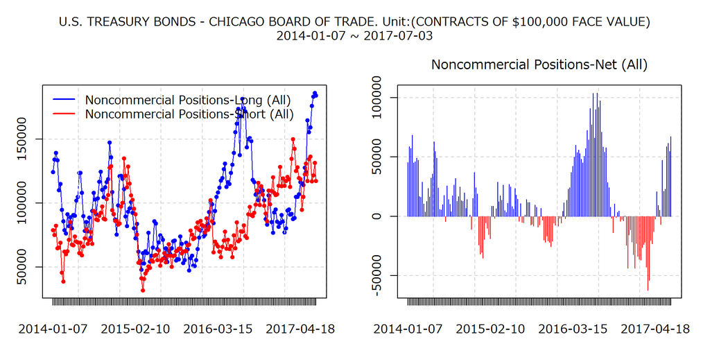

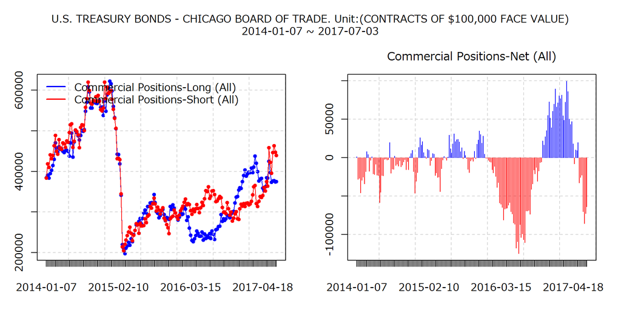

- ULTRA U.S. TREASURY BONDS - CHICAGO BOARD OF TRADE. Unit:(CONTRACTS OF $100,000 FACE VALUE)

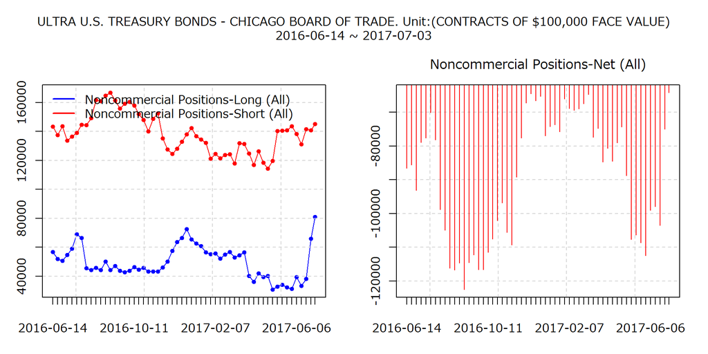

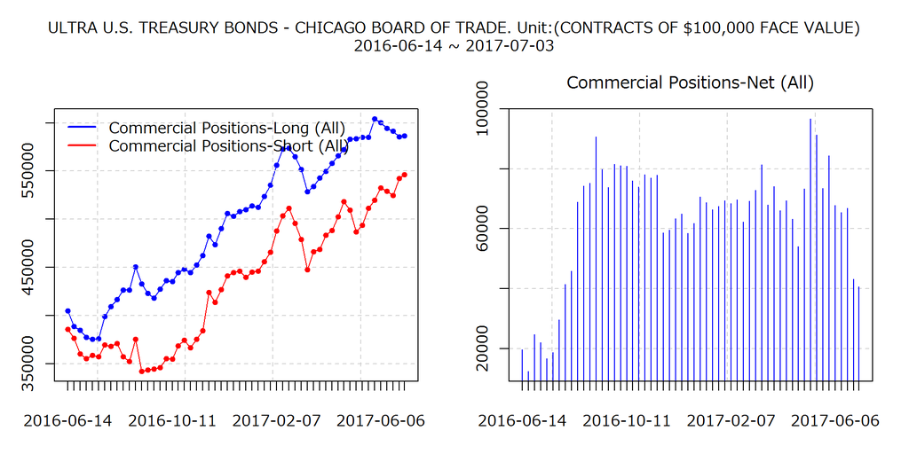

- 10-YEAR U.S. TREASURY NOTES - CHICAGO BOARD OF TRADE. Unit:(CONTRACTS OF $100,000 FACE VALUE)

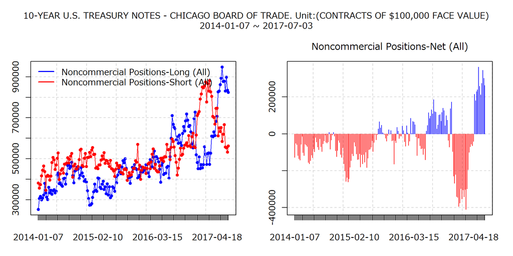

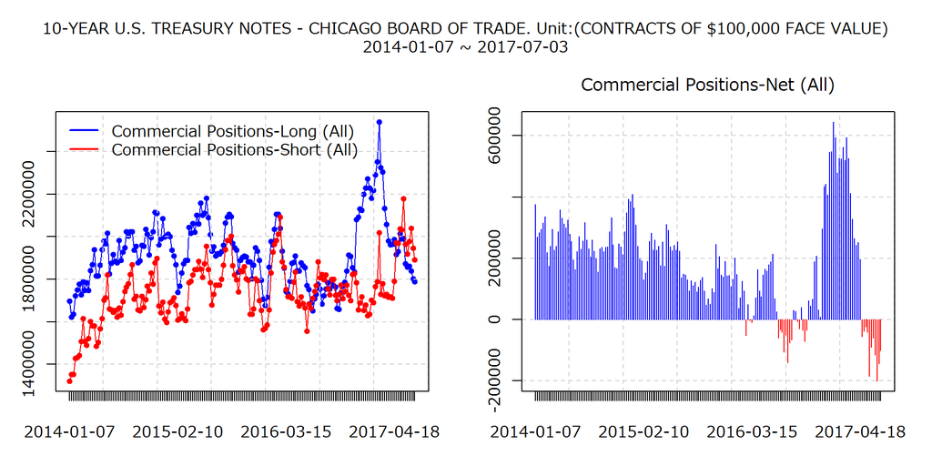

- JAPANESE YEN - CHICAGO MERCANTILE EXCHANGE. Unit:(CONTRACTS OF JPY 12,500,000)

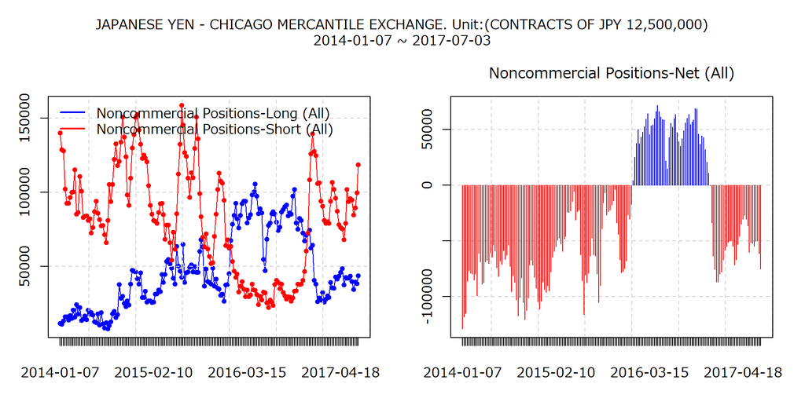

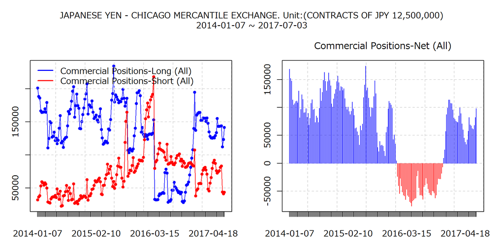

- U.S. DOLLAR INDEX - ICE FUTURES U.S.. Unit:(U.S. DOLLAR INDEX X $1000)

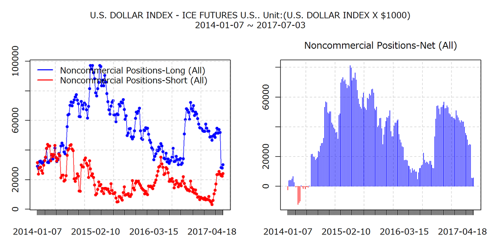

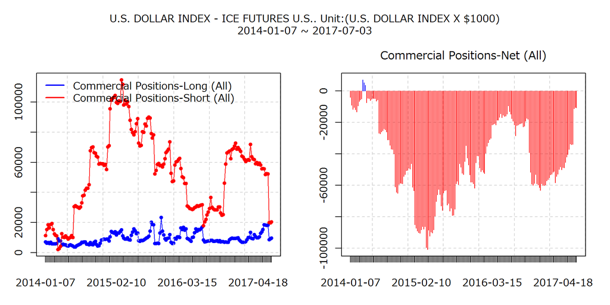

- VIX FUTURES - CBOE FUTURES EXCHANGE. Unit:($1000 X INDEX)

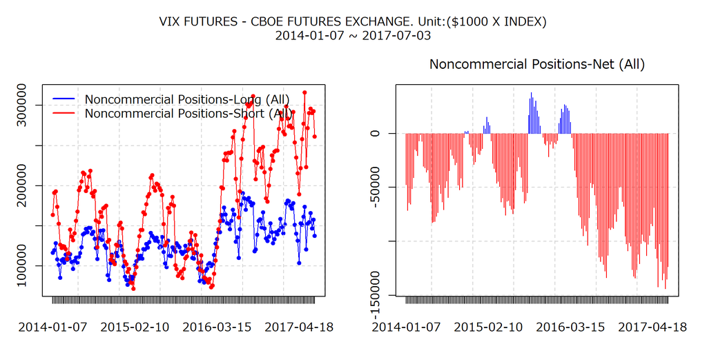

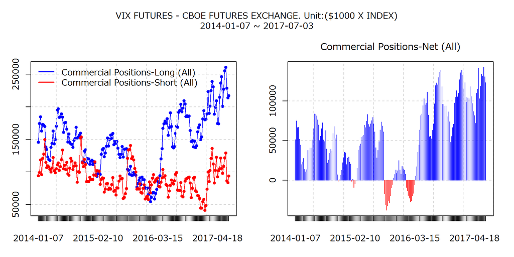

- SOUTH AFRICAN RAND - CHICAGO MERCANTILE EXCHANGE. Unit:(CONTRACTS OF ZAR 500,000)

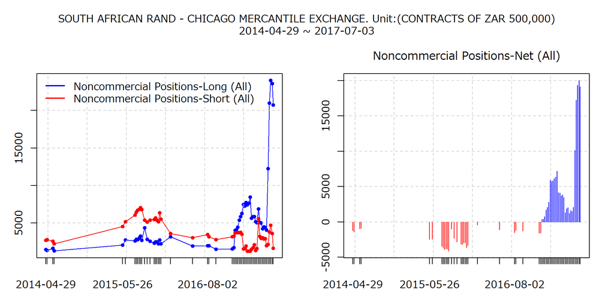

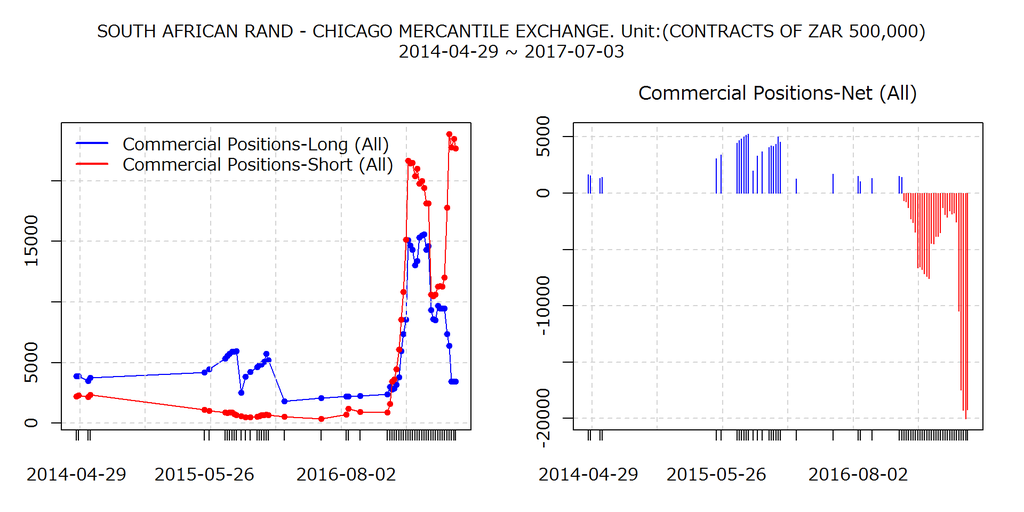

- DJIA Consolidated - CHICAGO BOARD OF TRADE. Unit:($10 X DJIA INDEX)

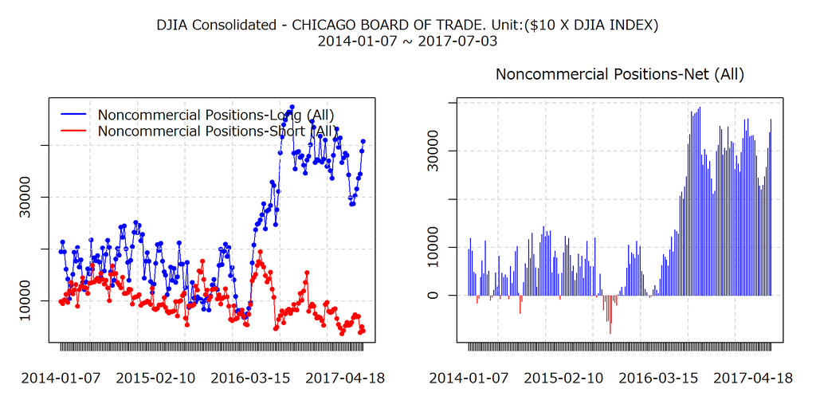

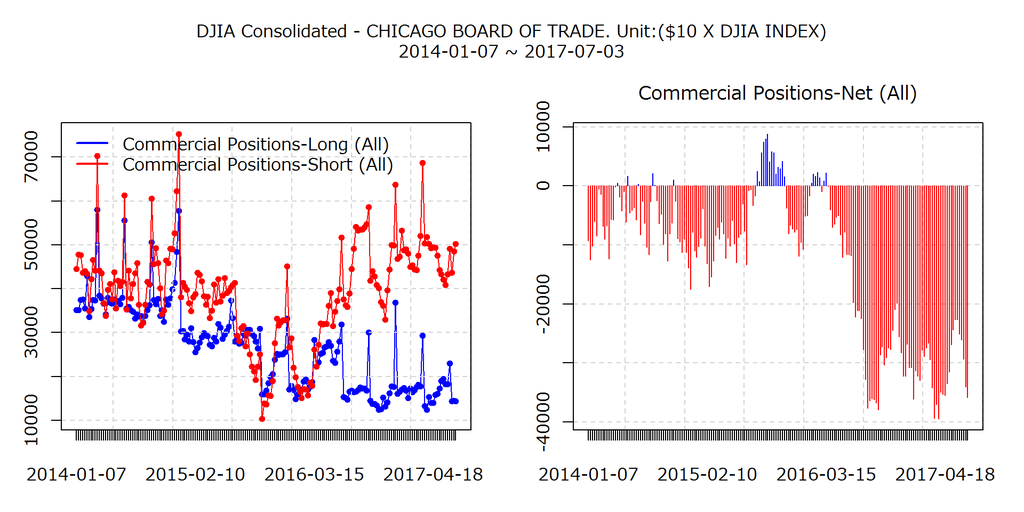

- NIKKEI STOCK AVERAGE - CHICAGO MERCANTILE EXCHANGE. Unit:(NIKKEI INDEX X $5.00)

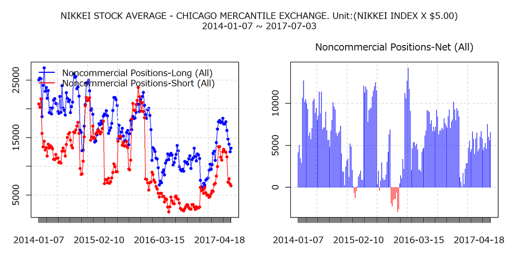

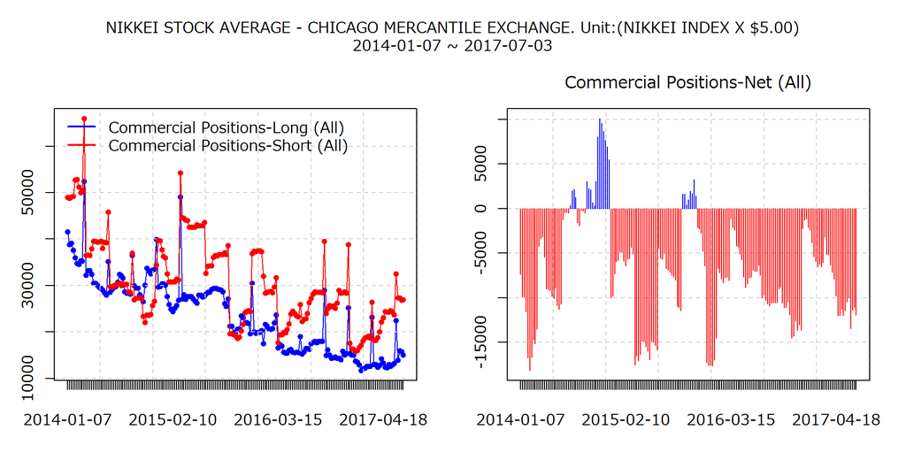

- NIKKEI STOCK AVERAGE YEN DENOM - CHICAGO MERCANTILE EXCHANGE. Unit:(NIKKEI INDEX X JPY 500)

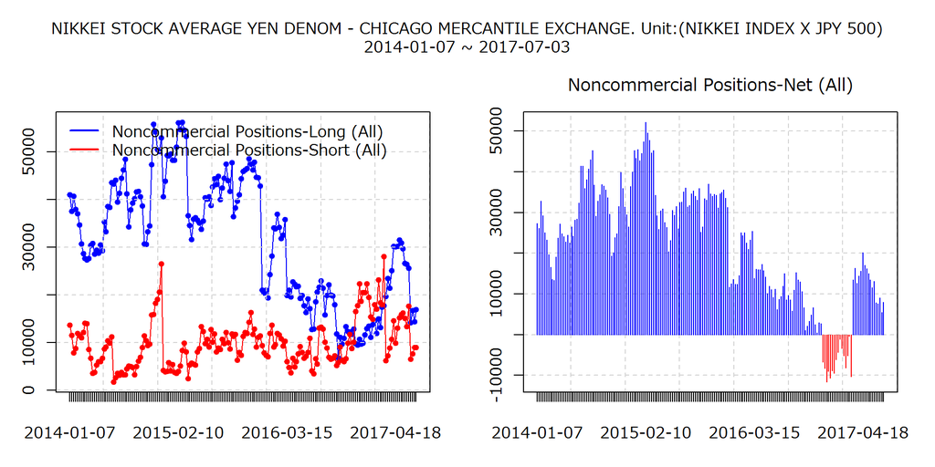

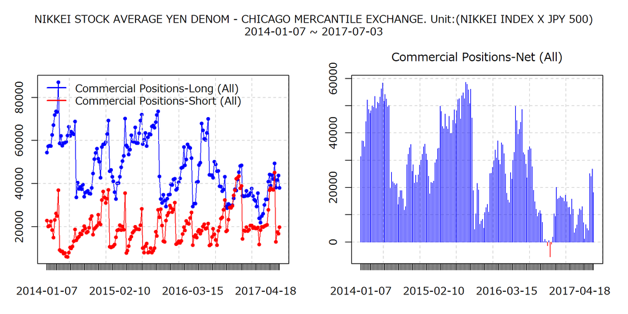